# HW5

```r
library(tidyverse)
library(countrycode)
library(dplyr)
library(MASS)
```

```r
#load the data
file_path <- file.choose()
load(file_path)

WVS = `WVS_Cross-National_Wave_7_v6_0` |> as.tibble()
```

```r
# This part clean all the data as required and return number of thorwing variable.

# make sure these three variable is addable
class(WVS$Q46)
```

```
[1] "integer"
```

```r
class(WVS$Q48)
```

```
[1] "integer"
```

```r
class(WVS$Q49)
```

```
[1] "integer"
```

```r
# Throw out all the negative data
WVS <- WVS %>%
  mutate(across(everything(), ~ ifelse(. < 0, NA, .)))

# Create the Well_being variable
WVS <- WVS %>% mutate(well_being = rowSums(across(c(Q46, Q48, Q49))))
head(WVS$well_being)
```

```
[1] 21 19 20 19 17 21
```

```r
# Throw out all the unnecessary feature
WVS_working <- WVS %>%
 dplyr:: select(-Q46, -Q56,-Q48,-Q49)

# Thorw out all the variable that not numeric except the required three variable,tracking the data I throw with non_numeric_var then create the the variable with using code provided last time..However, I different from the previous code, I keep gender as the numeric form so that I could keep it as a feature in the Lasso
non_numeric_vars <- WVS_working %>%
  dplyr::select(where(~ !is.numeric(.) & !is.integer(.))) %>%as.tibble()

non_numeric_vars<-names(non_numeric_vars)%>%as.tibble()





WVS_cleaned <- WVS_working %>%
  dplyr::select(c(B_COUNTRY_ALPHA, Q262, Q260), where(~ is.numeric(.) | is.integer(.)))


WVS_cleaned$Q260=ifelse(WVS_cleaned$Q260==0,NA,WVS_cleaned$Q260)

WVS_cleaned<-WVS_cleaned%>%rename(gender=Q260)


WVS_cleaned$age = ifelse(WVS_cleaned$Q262>15, WVS_cleaned$Q262, NA)

WVS_cleaned$country = countrycode(sourcevar = WVS_cleaned$B_COUNTRY_ALPHA,
                          origin = "iso3c",
                          destination = "country.name")
# thorw out all the varible with more than 20% NA,tracking the data I throw with the table "na_vars"

na_vars <- WVS_cleaned %>%
   dplyr::select(where(~ sum(is.na(.)) >= 0.2 * nrow(WVS_cleaned))) %>%
  names()

na_vars<-as.tibble((na_vars))


 WVS_cleaned <- WVS_cleaned %>%
   dplyr::select(where(~ sum(is.na(.)) <= 0.2 * nrow(WVS_cleaned)))

 WVS_cleaned <- na.omit(WVS_cleaned)
 number_of_thorw_variable<-sum(nrow(non_numeric_vars),nrow(na_vars))


 number_of_thorw_variable
```

```
[1] 172
```

```r
WVS_cleaned<-WVS_cleaned%>%na.omit()
```

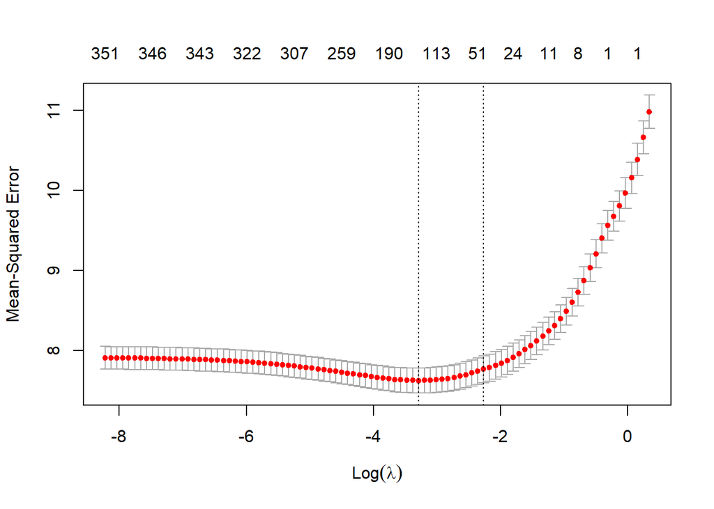

```r
library(glmnet)
# delete the variable that I do not want count them as features.
input_data <- WVS_cleaned %>%
  dplyr::select(-country,-B_COUNTRY_ALPHA,-Q262,-well_being)

 input_data<-as.matrix(input_data)


# start lasso
set.seed(666)
Y <- WVS_cleaned$well_being
cv_lasso <- cv.glmnet(input_data, Y, alpha = 1)

# this plot gives me the log of lambda change with MSE after conduct the CV, the two line give me the min lambda and the 1sd lambda
plot(cv_lasso)
```

```r
# condut the 1sd rule and the best model

onesd_lambda <- cv_lasso$lambda.1se


cv_lasso_final <- glmnet(input_data, Y, alpha = 1, lambda = onesd_lambda)
```

```r
# this chunck of data give the fist 10 importants data

library(ggplot2)
lasso_coef <- coef(cv_lasso_final)


coef_df <- data.frame(
  Feature = rownames(lasso_coef),
  Coefficient = as.numeric(lasso_coef)
) %>%
  filter(Feature != "(Intercept)") %>%
  arrange(desc(abs(Coefficient)))


top_10_features <- head(coef_df, 10)
print(top_10_features)
```

```
    Feature Coefficient
1       Q50  0.49720424
2  defiance -0.30544554
3      Q220  0.15224695
4  equality  0.14497899
5   I_NORM3 -0.14058545
6       Q47 -0.11781125
7      Q150  0.11334338
8      Q159  0.10136042
9      Q250  0.08823188
10     Q257 -0.07906610
```

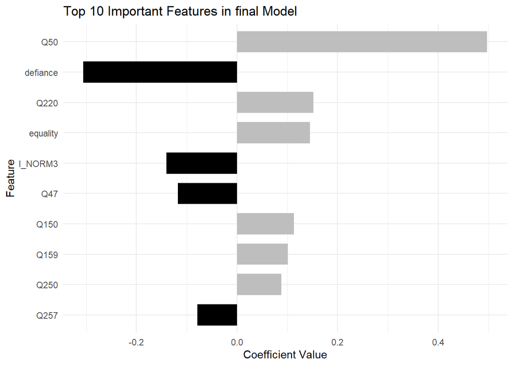

```r
ggplot(top_10_features, aes(x = reorder(Feature, abs(Coefficient)), y = Coefficient, fill = Coefficient > 0)) +
  geom_bar(stat = "identity", width = 0.7) +
  coord_flip() +
  labs(title = "Top 10 Important Features in final Model",
       x = "Feature",
       y = "Coefficient Value") +
  theme_minimal() +
  scale_fill_manual(values = c("black", "grey"), guide = FALSE)
```

1. **Q50 (Satisfaction with Financial Situation):** A higher level of satisfaction corresponds to a higher level of well-being, which makes sense.
2. **DEFIANCE:** A higher level of defiance corresponds to a lower level of well-being, which makes sense.
3. **Q220 (Possibility of Attending a Protest):** A lower likelihood of attending protests corresponds to a higher level of well-being, which makes sense.
4. **EQUALITY:** A higher level of equality corresponds to a higher level of well-being, which makes sense.
5. **I_NORM3:** It is difficult to determine, as it is a latent variable.
6. **Q47 (Health):** A higher score indicates a poorer health condition, so the negative relationship makes sense.
7. **Q150 (Freedom and Security):** This does not make sense to me since it should be treated as a factor rather than numeric data.
8. **Q159 (Opportunities for the Next Generation with Technology):** Greater confidence leads to better well-being, which makes sense.
9. **Q250 (Importance of Democracy):** This does not make sense, as it should be treated as a categorical variable rather than numeric data.
10. **Q257(Feel close to the country):**The lower feeling of close to country,the lower level of well being. This doesn’t make sense to me

They do not include age and gender, I think it is ok, because it may indicate they are not important feature of predicting well_being

```r
# This chunck run a lm model with top 10 varible, gender and country, the summary table summary the coefficient and importance of all my variable.

lm_model_data <- WVS_cleaned %>%
  dplyr::select(Q50, defiance, equality, Q220, I_NORM3, Q150, Q47, Q159, Q257, Q250,gender,country,well_being)

# convert country and gender as factor

lm_model_data <- lm_model_data %>%
  mutate(gender = case_when(
    gender == 1 ~ "male",
    gender == 2 ~ "female"
  ))

lm_model_data <- lm_model_data %>%
  mutate(
    gender = as.factor(gender),
    country = as.factor(country)
  )


lm_model<-lm(well_being~Q50+ defiance+equality+Q220+I_NORM3+Q150+Q47+Q159+Q257+Q250+gender+country,data=lm_model_data)


summary(lm_model)
```

```
Call:
lm(formula = well_being ~ Q50 + defiance + equality + Q220 +
    I_NORM3 + Q150 + Q47 + Q159 + Q257 + Q250 + gender + country,
    data = lm_model_data)

Residuals:
     Min       1Q   Median       3Q      Max
-15.7408  -1.5346   0.2046   1.7520  10.5874

Coefficients:
                   Estimate Std. Error t value Pr(>|t|)
(Intercept)        10.21113    0.50620  20.172  < 2e-16 ***
Q50                 0.54447    0.01738  31.331  < 2e-16 ***
defiance           -0.89155    0.24264  -3.674 0.000241 ***
equality            0.65855    0.18589   3.543 0.000399 ***
Q220                0.23717    0.06564   3.613 0.000305 ***
I_NORM3            -0.28827    0.08199  -3.516 0.000441 ***
Q150                0.33071    0.08094   4.086 4.45e-05 ***
Q47                -0.19139    0.04786  -3.999 6.45e-05 ***
Q159                0.17807    0.01696  10.499  < 2e-16 ***
Q257               -0.15089    0.05038  -2.995 0.002756 **
Q250                0.15525    0.01844   8.418  < 2e-16 ***
gendermale          0.14401    0.07821   1.841 0.065631 .
countryBangladesh  -0.98494    0.42820  -2.300 0.021474 *
countryBolivia     -0.38920    0.39054  -0.997 0.319026
countryChile       -0.15110    0.46542  -0.325 0.745457
countryColombia    -0.15497    0.43636  -0.355 0.722500
countryCzechia     -0.25879    0.37045  -0.699 0.484833
countryEcuador     -0.47424    0.39267  -1.208 0.227204
countryIndonesia   -0.29543    0.39437  -0.749 0.453815
countryMexico       0.55475    0.36534   1.518 0.128958
countryMongolia    -1.23975    0.37087  -3.343 0.000835 ***
countryNicaragua    0.32302    0.37284   0.866 0.386313
countryPakistan    -0.57993    0.40654  -1.427 0.153776
countryPhilippines -0.78348    0.37168  -2.108 0.035083 *
countrySouth Korea -0.49463    0.36776  -1.345 0.178684
countryThailand    -1.61439    0.40763  -3.960 7.57e-05 ***
countryUruguay      0.39748    0.44822   0.887 0.375228
---
Signif. codes:  0 '***' 0.001 '**' 0.01 '*' 0.05 '.' 0.1 ' ' 1

Residual standard error: 2.786 on 5667 degrees of freedom
Multiple R-squared:  0.2976,    Adjusted R-squared:  0.2944
F-statistic: 92.34 on 26 and 5667 DF,  p-value: < 2.2e-16
```